# Assignment 1

Johnson Mawuli

2023-03-10

VECTORS Question 1 A. Creating a vector of values

```r
values <- c()
for (i in 1:25) {
  values[i] <- (2^i)/i
}
values
```

```
##  [1] 2.000000e+00 2.000000e+00 2.666667e+00 4.000000e+00 6.400000e+00
##  [6] 1.066667e+01 1.828571e+01 3.200000e+01 5.688889e+01 1.024000e+02
## [11] 1.861818e+02 3.413333e+02 6.301538e+02 1.170286e+03 2.184533e+03
## [16] 4.096000e+03 7.710118e+03 1.456356e+04 2.759411e+04 5.242880e+04
## [21] 9.986438e+04 1.906502e+05 3.647221e+05 6.990507e+05 1.342177e+06
```

B. Execute the following lines which create two vectors of random integers which are chosen with replacement from the integers 0, 1,. . . , 999. Both vectors have length 250.

```r
set.seed(50)
x <- sample(0:999, 250, replace = TRUE)
y <- sample(0:999, 250, replace = TRUE)
```

SUB QUESTIONS/ANSWERS

```r
# A
#Removing the first value in y aand the last value in x since its shifted by 1 position
X <- x[1:249]
Y <- y[2:250]

## using mapply
z <- mapply(function(i,j) j - i, X, Y)
z # vector of (y2 − x1, . . . , yn − xn−1).
```

```
##   [1] -359  692 -724   40 -626 -719 -809  527  -89 -829  248  144 -749 -352 -220
##  [16] -249  387 -492   85 -106  303  -97 -436  146  282 -206 -385  -96 -567 -757
##  [31]  287  277 -562  292  -89  -93 -847 -822 -203  679  309 -199 -273    4  -47
##  [46]  142  122  414 -602 -304 -674   -8 -662 -168 -349  -63 -221  115    1 -600
##  [61] -382 -487    2  375   19 -113 -634  107   60   47  214 -325  -49 -290  169
##  [76]  290 -624  457 -408  581 -189  204  -80  409  209 -410  461   37 -127  185
##  [91]  382 -446   44  -56 -270 -598 -378 -155  134 -187  109  316 -139  158  305
## [106]  -39 -119  182  441 -403 -107  615  614 -378 -464   31 -385  665  674 -217
## [121] -279 -406  -45 -489 -350 -451  -18  660  504   -6   60 -130 -379 -302 -219
## [136]  -21  438  129 -201 -275  131  694  -96 -176  117 -113  887 -439 -126 -148
## [151]  392 -158  444 -291  232  -12 -274  477 -510  336 -759 -363 -195 -220  160
## [166] -308 -333  302 -183  227  -12  428  665 -301   -8  222  -50 -444 -425 -650
## [181] -424  318  154  238 -727   71  472  908  265  654 -644 -754  657 -382 -313
## [196]  910 -381  394 -596  602  397 -572  378 -274 -271  601 -791 -378 -461   39
## [211]  163 -118 -332 -170  -94  262 -474  566 -273 -366 -400  374   42  100  135
## [226]  609 -527  580 -219  128 -524  620 -206  410 -280  -66  -50  252  279   48
## [241] -595  -59 -623  247  514   62 -102  475  287
```

```r
#or
h <- y[-1] - x[-length(x)]
h
```

```
##   [1] -359  692 -724   40 -626 -719 -809  527  -89 -829  248  144 -749 -352 -220
##  [16] -249  387 -492   85 -106  303  -97 -436  146  282 -206 -385  -96 -567 -757
##  [31]  287  277 -562  292  -89  -93 -847 -822 -203  679  309 -199 -273    4  -47
##  [46]  142  122  414 -602 -304 -674   -8 -662 -168 -349  -63 -221  115    1 -600
##  [61] -382 -487    2  375   19 -113 -634  107   60   47  214 -325  -49 -290  169
##  [76]  290 -624  457 -408  581 -189  204  -80  409  209 -410  461   37 -127  185
##  [91]  382 -446   44  -56 -270 -598 -378 -155  134 -187  109  316 -139  158  305
## [106]  -39 -119  182  441 -403 -107  615  614 -378 -464   31 -385  665  674 -217
## [121] -279 -406  -45 -489 -350 -451  -18  660  504   -6   60 -130 -379 -302 -219
## [136]  -21  438  129 -201 -275  131  694  -96 -176  117 -113  887 -439 -126 -148
## [151]  392 -158  444 -291  232  -12 -274  477 -510  336 -759 -363 -195 -220  160
## [166] -308 -333  302 -183  227  -12  428  665 -301   -8  222  -50 -444 -425 -650
## [181] -424  318  154  238 -727   71  472  908  265  654 -644 -754  657 -382 -313
## [196]  910 -381  394 -596  602  397 -572  378 -274 -271  601 -791 -378 -461   39
## [211]  163 -118 -332 -170  -94  262 -474  566 -273 -366 -400  374   42  100  135
## [226]  609 -527  580 -219  128 -524  620 -206  410 -280  -66  -50  252  279   48
## [241] -595  -59 -623  247  514   62 -102  475  287
```

```r
## b
Yvalue <- numeric(length(y))
for (i in 2:length(y)) {
  Yvalue[i] <- sin(y[i - 1])
}

Xvalues<- cos(x)

n <- Yvalue/Xvalues
n
```

```
##   [1]   0.000000000  -0.251172387  -1.714506221  -1.020534796   1.903299501
##   [6]   4.119691628   0.474814101   0.989633106   1.157740470  -2.882161424
##  [11]   1.394557843   3.580223541  -0.664006287   0.847013135  -1.095954285
##  [16]   0.469790086  -0.544605141  -1.253304942  -0.353697082  -1.357919064
##  [21]  -1.271051804   0.009344711 -10.576799813  -0.674196809  -2.087577737
##  [26] -32.238631575  -4.966988605  -0.490160550  -0.043753175  -1.766774293
##  [31]  -2.456887042  -1.034891510  -0.118782199   0.036938122  -0.173612680
##  [36]   0.851649079  -0.353501116  -1.024989992   0.589100687   4.018304788
##  [41]  -1.004929483   0.977012057   0.952499185  -0.553614203   1.115864382
##  [46]   1.254898524   1.155274507  -1.032061497   0.906767318  -0.945760017
##  [51]   2.658291106  -1.254932608  -0.547511538   3.928248333  -3.673653649
##  [56]  -0.127796877  -3.226308105  -0.894400173   0.701414603   2.128023689
##  [61]  -0.414254810  -0.917829147   0.558286542   0.000000000  -0.564183939
##  [66]   0.946409854   1.407199013   0.800206658  -1.146531865   1.181638746
##  [71]   0.495187680   1.446378081  -1.004546310  -0.648760582  -0.909533924
```

[output cut: 35 more lines]

```r
##c
XVal1 <- c()
for (i in 3:250) {
  XVal1[i] <- x[i - 2] + 2*x[i - 1] - x[i]
}
XVal1
```

```
##   [1]   NA   NA -432 1554  145  937 1811 2133  855  883 2241 1428 -681 1225 2238
##  [16]  842  885  391 1031 1982 1288  798  416 1618 1932 1055 2127 1157 1459  956
##  [31] 2323 1263 -426 1014  880 -276  863 1761 2374 1379  344  434 1629 1203 2177
##  [46]  682   58 1226  815 1005 1830 2686  320 1871  700 1189 1356 2095  818 -840
##  [61] 1403 1790 1343  564  803  303 1559 2033 1126  711 1608  614  976 2108 1821
##  [76]  473 -281 1586  473 1755  263 1559   -3 1558 1209  -98  846 1131  848  778
##  [91]  350 -508 1253   37 1380 1064  799 1816 2216  816 1445 1179  931 1474  394
## [106] 1219  556 1333 1798  406 1122 1175  636  135  676 1807 1514 1387  531  154
## [121]  478  408 2011 1071 1427 1472 2076 1747  369 -343 1252  997  400  790 1398
## [136] 2042  776  689 1589  547 1510  934 -289  978 1202 -593 1834  228 1515 1275
## [151]  452  979 1210  804 1813  794  435 1688  948  914 1012 1244 1965 1456 1683
## [166]  798 1463 2673  608 1735  204 1100  713  462  352 1109 2028  401 1380 1531
## [181] 1223 1660 1373  632 -148 1321 2084 1650  112  559  147  552 2410  782  703
## [196] 2550  354 1500  368 1147  673 -268 1355 1719  506 2061  279  813 1833 1976
## [211] 2057 2043 1030 1081  963  808 -241 1331  488  470 1993 1412  454 1210 2389
## [226]  835 -187 1162 -177 2083  286 1363  478  423  308 1123   43 1458  964 1250
## [241]  750 1493 2121 2040  760  761  445 1787 1083 -306
```

Question 3 A

```r
s <- sqrt(abs(x - mean(x)))
s
```

```
##   [1] 12.638513 22.731740 17.095847 20.802211 18.310325 18.822008 16.919456
##   [8] 12.358479 13.389100 19.397629 15.991623 22.577245 21.430539 15.403506
##  [15] 15.834519  7.261680 13.701533 15.305816 17.414592  9.366536 10.331118
##  [22]  6.762544 20.958721 16.378889  9.862454 21.477151  7.330211 15.819861
##  [29]  6.424017 20.742902 19.176340 22.687706  9.070171 17.627592 19.124121
##  [36] 16.948982 19.981692 19.449113 12.834796 16.635264  2.954996 18.035188
##  [43]  8.140516 17.557562 20.993618 14.203239 12.299106  8.469475 15.692928
##  [50] 21.662594 20.205643 18.620741 21.172340 16.362518 16.317720 11.369609
##  [57] 14.908655 21.627113 21.857081 21.685663 10.642744  6.303332 15.991623
##  [64]  7.856971 11.346013 20.766993 15.108541  9.577682  5.266118 13.973833
##  [71] 13.846732 15.851435 19.704517  5.170300 20.802211 17.655934 16.681367
##  [78] 16.962665 16.830567 20.560447 15.108541 21.719392 18.473440 17.138611
##  [85] 20.043253  7.366682  9.259158 13.954641 16.423520 21.418030 21.993908
##  [92] 11.630477 20.315807 18.062890  9.313002 11.927615 21.266594 16.860249
##  [99] 11.905125 15.435932  7.532065  0.855570  8.016733 17.109413 11.758741
```

[output cut: 21 more lines]

B. How many values in y are greater than 200?

```r
f <- y>200
f
```

```
##   [1]  TRUE FALSE  TRUE FALSE FALSE  TRUE FALSE FALSE  TRUE  TRUE FALSE  TRUE
##  [13] FALSE  TRUE  TRUE FALSE  TRUE  TRUE  TRUE  TRUE  TRUE  TRUE  TRUE  TRUE
##  [25]  TRUE  TRUE  TRUE FALSE  TRUE FALSE FALSE  TRUE  TRUE FALSE  TRUE FALSE
##  [37]  TRUE FALSE FALSE FALSE  TRUE  TRUE  TRUE  TRUE  TRUE FALSE  TRUE  TRUE
##  [49]  TRUE FALSE  TRUE  TRUE FALSE  TRUE FALSE  TRUE  TRUE  TRUE FALSE FALSE
##  [61]  TRUE  TRUE FALSE  TRUE  TRUE  TRUE  TRUE FALSE  TRUE  TRUE  TRUE  TRUE
##  [73]  TRUE  TRUE  TRUE  TRUE  TRUE FALSE  TRUE  TRUE  TRUE  TRUE  TRUE  TRUE
##  [85]  TRUE  TRUE FALSE  TRUE  TRUE FALSE  TRUE  TRUE  TRUE FALSE  TRUE FALSE
##  [97] FALSE  TRUE  TRUE  TRUE  TRUE  TRUE  TRUE  TRUE  TRUE  TRUE  TRUE  TRUE
## [109]  TRUE  TRUE  TRUE  TRUE  TRUE  TRUE  TRUE  TRUE  TRUE FALSE  TRUE  TRUE
## [121] FALSE  TRUE  TRUE  TRUE  TRUE  TRUE  TRUE  TRUE  TRUE  TRUE  TRUE  TRUE
## [133]  TRUE  TRUE  TRUE  TRUE  TRUE  TRUE  TRUE FALSE  TRUE  TRUE  TRUE  TRUE
## [145] FALSE FALSE  TRUE  TRUE  TRUE  TRUE FALSE  TRUE  TRUE  TRUE  TRUE  TRUE
## [157]  TRUE  TRUE  TRUE FALSE  TRUE FALSE  TRUE  TRUE  TRUE  TRUE  TRUE  TRUE
## [169]  TRUE  TRUE  TRUE  TRUE  TRUE  TRUE FALSE  TRUE  TRUE  TRUE  TRUE  TRUE
## [181] FALSE  TRUE  TRUE  TRUE  TRUE FALSE  TRUE  TRUE  TRUE  TRUE  TRUE FALSE
## [193]  TRUE  TRUE  TRUE  TRUE  TRUE  TRUE  TRUE FALSE  TRUE  TRUE  TRUE  TRUE
## [205] FALSE  TRUE  TRUE FALSE  TRUE  TRUE  TRUE  TRUE  TRUE FALSE FALSE FALSE
## [217]  TRUE  TRUE  TRUE  TRUE  TRUE FALSE  TRUE  TRUE  TRUE  TRUE  TRUE FALSE
## [229]  TRUE  TRUE FALSE FALSE  TRUE FALSE  TRUE  TRUE FALSE  TRUE  TRUE  TRUE
## [241]  TRUE  TRUE  TRUE FALSE  TRUE  TRUE  TRUE  TRUE  TRUE  TRUE
```

```r
summary(f)
```

```
##    Mode   FALSE    TRUE
## logical      55     195
```

```r
mh <- sum(f)
mh
```

```
## [1] 195
```

```r
print(paste(mh, "values in y are greater than 200 "))
```

```
## [1] "195 values in y are greater than 200 "
```

C. Sorting the numbers in the vector x in the order of increasing values in yVec.

```r
x[order(y, decreasing = FALSE)]
```

```
##   [1] 271 725 957 151 374  10 919 996 325 120 216 978 997 409 474 261 607 979
##  [19] 814 271 905 362 692 746 777 793 130  94 257 840 892 435  68 703 862  23
##  [37] 949 853 250 986 813 669 996 441 504 975  49  46  98 239 274 358 598 799
##  [55] 159 885  94 150 114 611 650 339 988 778 881 344 764 189 247 391 180  43
##  [73] 541 487 635 868 180 865 215 830 465 521 253 609  78 440 618 799 259 835
##  [91] 960 921 420 581 927 711 752 257 346 102 966 272 665 640 563 104 887 510
## [109] 276 958 160 855 662 795  40 450 648 656  12 234 915 362 765 800 678 786
## [127] 769 485 251 598 926 805 161 449 310 924 369 777  17 765  59 795 367 499
## [145] 498 778 274 450 651 722 954  55 470 526 469 749 477  31 962 811 903 113
## [163] 201 873 212 324 218 125  78 593 680 961 385 963 646 705 317 523 610 568
## [181] 755 139 935 810 211 319 161 983 819 839 926 481 761 770 227 601 232 566
## [199]   3 335 605 473 814 233 402 221 206 286 440 455 852  87  86 398 591 755
## [217] 576 827 500 261 687 773 438 665 640 388 706 332 708 988  25 439 397  79
## [235] 518 376 624 778 777 512 398 757 345 895 667 762 387 561 258 390
```

D. Selecting the entries in xless than 300 and greater than 600 and putting them in a container.

```r
D <- x[x < 300]
B <- x[x > 600]
xnew <- c(D, B)
xnew
```

```
##   [1]  10  94 271  17 276 159  12 216 161 250  86 180 259  59  49 271  94 215
##  [19] 239 104  55 233 125 257  68  43 114 234 221 253 261 130 206  40 161 274
##  [37] 286 160  78  23  87 251 212  31 201 258 232 272  25 218 247  78 102 151
##  [55] 227 113 274  98 189  79 150 120   3  46 257 180 261 211 139 819 862 881
##  [73] 813 706 903 986 764 761 830 966 795 624 988 777 957 609 814 926 905 852
##  [91] 835 678 773 996 935 975 793 656 749 997 640 958 755 722 778 915 805 810
## [109] 755 868 662 853 669 979 811 765 665 799 610 646 640 865 988 855 752 887
## [127] 705 611 778 769 667 692 605 949 895 777 786 607 778 919 651 765 963 961
## [145] 777 635 746 770 885 648 650 725 924 799 665 996 708 960 762 873 618 892
## [163] 839 978 962 926 757 711 601 921 814 827 983 703 840 680 954 927 687 800
## [181] 795
```

3. MATRICES Create a 6 × 10 matrix of random integers chosen from 1, 2,. . . , 10 by executing the following two lines of code:

```r
set.seed(75)
A <- matrix(sample(10, size = 60, replace = TRUE), nrow = 6)
A
```

```
##      [,1] [,2] [,3] [,4] [,5] [,6] [,7] [,8] [,9] [,10]
## [1,]    8    8    8    7    7    5    2    2    6     5
## [2,]    9    5    2    6    6    1    6    6    3     7
## [3,]    5    1   10    2    5    6    8    9   10     8
## [4,]    9    3    1    1    6   10   10    7    9    10
## [5,]    7    3    3    3    6    4    4    6   10     2
## [6,]    9    3    3    4    1    2    1   10    6     1
```

A Find the column and row sums. You can use apply() function.

```r
#Finding the column sums
colSums(A)
```

```
##  [1] 47 23 27 23 31 28 31 40 44 33
```

```r
## we can also use APPLY
apply(A, 2, sum)
```

```
##  [1] 47 23 27 23 31 28 31 40 44 33
```

```r
##Finding the row sum
rowSums(A)
```

```
## [1] 58 51 64 66 48 40
```

```r
## or USING APPLY
apply(A, 1, sum)
```

```
## [1] 58 51 64 66 48 40
```

B Find the index of rows whose totals are greater than 50.

```r
which(rowSums(A) > 50)
```

```
## [1] 1 2 3 4
```

C Which rows contain exactly two occurrences of the number seven?

```r
which(apply(A, 1, function(x) sum(x == 7)) == 2)
```

```
## [1] 1
```

```r
##or

for(i in 1:nrow(A)){
  if(any(sum(A[i,] == 7) == 2)) {
    print(paste("row ", i, " has two occurences of the number seven "))
  }else{
    print(paste("row ", i, " has no two occurences"))
  }
}
```

```
## [1] "row  1  has two occurences of the number seven "
## [1] "row  2  has no two occurences"
## [1] "row  3  has no two occurences"
## [1] "row  4  has no two occurences"
## [1] "row  5  has no two occurences"
## [1] "row  6  has no two occurences"
```

D Find the number of entries in each row which are greater than 4. You can use apply() function

```r
apply(A > 4, 1, sum)
```

```
## [1] 8 7 8 7 4 3
```

Russian Roulette

```r
?sample
sample(c("CLICK", "BANG"), size = 1, replace = FALSE, prob=c(5/6,1/6))
```

```
## [1] "BANG"
```

3. FUNCTIONS

```r
myfunction <- function(x){
  ifelse(x < 0, x^2 +(2*x) +3, x +3)
  ifelse(x >= 2, x^2 + (4*x) - 7, x+3)
}
 myfunction(-1)
```

```
## [1] 2
```

```r
 myfunction(1)
```

```
## [1] 4
```

```r
 myfunction(3)
```

```
## [1] 14
```

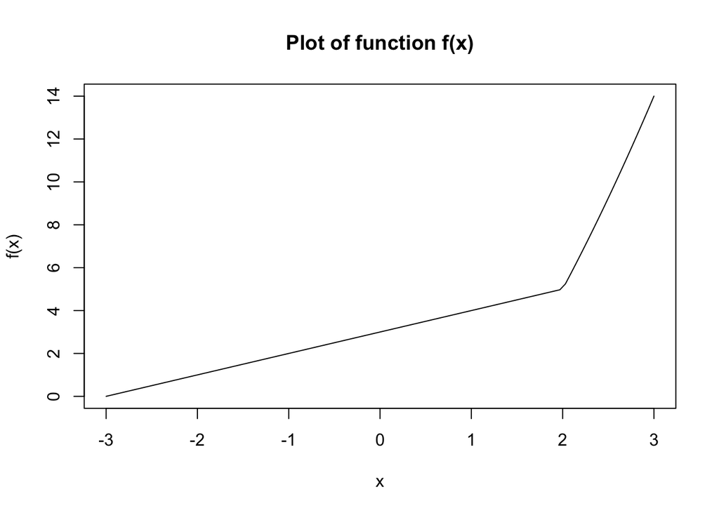

```r
library(ggplot2)
x <- seq(-3, 3, length.out = 100)
y <- myfunction(x)
plot(x, y, type = "l", xlab = "x", ylab = "f(x)", main = "Plot of function f(x)")
```

```r
x <- c(-10:10)
y <- myfunction(x)
print(y)
```

```
##  [1]  -7  -6  -5  -4  -3  -2  -1   0   1   2   3   4   5  14  25  38  53  70  89
## [20] 110 133
```

4. CONDITIONS

```r
set.seed(2)
d <- sample(-10:10, 10, replace = TRUE)
d
```

```
##  [1] 10  4 -5 -5 -3  6  6  1 -2  7
```

```r
#taking the sqrt of the numbers by skipping the (-)
ifelse(d >= 0, sqrt(d), d)
```

```
##  [1]  3.162278  2.000000 -5.000000 -5.000000 -3.000000  2.449490  2.449490
##  [8]  1.000000 -2.000000  2.645751
```

5. LOOPS

A

```r
js <- c()

for(i in 1:length(d)){
  if(d[i] > 0){
    js[i] <- sqrt(d[i])
  }else{
    js[i] <- d[i]
  }
}
js
```

```
##  [1]  3.162278  2.000000 -5.000000 -5.000000 -3.000000  2.449490  2.449490
##  [8]  1.000000 -2.000000  2.645751
```

B

```r
# Initialize containers
means <- numeric(100)
sds <- numeric(100)

# Loop through 100 iterations
for (i in 1:100) {
  # Draw 1000 numbers from standard normal distribution
  samplee <- rnorm(1000)

  # Calculate mean and standard deviation
  means[i] <- mean(samplee)
  sds[i] <- sd(samplee)
}

# View results
print(means)
```

```
##   [1] -0.0530999281  0.0018550294 -0.0298169253 -0.0013366293  0.0257461579
##   [6] -0.0187894566  0.0139244331 -0.0052314524  0.0117511532 -0.0112348059
##  [11] -0.0182005030  0.0215589430 -0.0097138056 -0.0330777599  0.0047341909
##  [16] -0.0106174695  0.0285891003  0.0042145809  0.0014736761  0.0466348227
##  [21]  0.0341566424 -0.0117792774  0.0152269000 -0.0280360482 -0.0150621960
##  [26]  0.0525705075  0.0502425212 -0.0319737149 -0.0072937746 -0.0507238504
##  [31] -0.0071362540  0.0139188214  0.0572941364 -0.0021735115 -0.0552623236
##  [36]  0.0113618399 -0.0226293268 -0.0232607052  0.0073500208  0.0116394490
##  [41]  0.0513224496  0.0179969864 -0.0105519041 -0.0175718826  0.0106944977
##  [46]  0.0313720726  0.0239804390  0.0050990794 -0.0072936632  0.0149101452
##  [51] -0.0272951338  0.0595856165  0.0183772393  0.0480630192 -0.0259948008
##  [56] -0.0414991501 -0.0079345056 -0.0019903391  0.0133829062  0.0051048595
##  [61]  0.0209134046  0.0190723409  0.0073926131 -0.0076635909 -0.0305963007
##  [66]  0.0363258401  0.0013240055  0.0089274140 -0.0501517237 -0.0171553735
##  [71] -0.0268276861 -0.0132305025 -0.0148719032 -0.0065360211  0.0230366759
##  [76]  0.0437809166  0.0776182344 -0.0034032263 -0.0057870098 -0.0825934662
##  [81] -0.0160718175 -0.0003760641  0.0303260915  0.0034666648 -0.0752982406
##  [86]  0.0367751735  0.0317528934  0.0035964851  0.0169755111  0.0118783494
##  [91]  0.0176792566 -0.0013606060  0.0506129222 -0.0137339647  0.0573862301
##  [96] -0.0664272445  0.0175588146 -0.0998802859 -0.0554896987  0.0306469653
```

```r
print(sds)
```

```
##   [1] 1.0473622 0.9881780 1.0193836 1.0000049 1.0032742 1.0594077 1.0219239
##   [8] 1.0087731 1.0036007 1.0516438 1.0049924 0.9863282 0.9996190 0.9452326
##  [15] 0.9997889 1.0653710 0.9730923 1.0512761 1.0039740 0.9948130 1.0085496
##  [22] 1.0089805 1.0018946 1.0075772 0.9926361 0.9962670 1.0273700 0.9770540
##  [29] 0.9885554 0.9714797 1.0173289 0.9846739 1.0067945 1.0173685 1.0165381
##  [36] 0.9898979 0.9892518 1.0054921 0.9883007 0.9545360 1.0140051 1.0167940
##  [43] 1.0569727 0.9928746 1.0070681 1.0167390 0.9685684 0.9833102 1.0081370
##  [50] 0.9742906 0.9918838 1.0194770 0.9780103 0.9850078 0.9714196 0.9524764
##  [57] 0.9982537 1.0418310 1.0013398 0.9913432 0.9730238 0.9634267 1.0115160
##  [64] 0.9516095 0.9989078 0.9733215 1.0141766 0.9931865 0.9894949 1.0079194
##  [71] 1.0120326 1.0383155 0.9735886 0.9716425 1.0080779 0.9931094 1.0342626
##  [78] 0.9835722 1.0287983 1.0293388 1.0090412 1.0183400 0.9880030 1.0337441
##  [85] 0.9645728 1.0210041 0.9588952 0.9795829 1.0078435 1.0081885 1.0245831
##  [92] 1.0135168 1.0338857 0.9857574 1.0318442 1.0137546 0.9987738 1.0122330
##  [99] 0.9836252 0.9663773
```

C

```r
str(mtcars)
```

```
## 'data.frame':    32 obs. of  11 variables:
##  $ mpg : num  21 21 22.8 21.4 18.7 18.1 14.3 24.4 22.8 19.2 ...
##  $ cyl : num  6 6 4 6 8 6 8 4 4 6 ...
##  $ disp: num  160 160 108 258 360 ...
##  $ hp  : num  110 110 93 110 175 105 245 62 95 123 ...
##  $ drat: num  3.9 3.9 3.85 3.08 3.15 2.76 3.21 3.69 3.92 3.92 ...
##  $ wt  : num  2.62 2.88 2.32 3.21 3.44 ...
##  $ qsec: num  16.5 17 18.6 19.4 17 ...
##  $ vs  : num  0 0 1 1 0 1 0 1 1 1 ...
##  $ am  : num  1 1 1 0 0 0 0 0 0 0 ...
##  $ gear: num  4 4 4 3 3 3 3 4 4 4 ...
##  $ carb: num  4 4 1 1 2 1 4 2 2 4 ...
```

```r
df <- mtcars

for(i in 1:ncol(df)){
  if(length(unique(df[,i])) < 5){df[,i] <- as.factor(df[,i])}
}
str(df)
```

```
## 'data.frame':    32 obs. of  11 variables:
##  $ mpg : num  21 21 22.8 21.4 18.7 18.1 14.3 24.4 22.8 19.2 ...
##  $ cyl : Factor w/ 3 levels "4","6","8": 2 2 1 2 3 2 3 1 1 2 ...
##  $ disp: num  160 160 108 258 360 ...
##  $ hp  : num  110 110 93 110 175 105 245 62 95 123 ...
##  $ drat: num  3.9 3.9 3.85 3.08 3.15 2.76 3.21 3.69 3.92 3.92 ...
##  $ wt  : num  2.62 2.88 2.32 3.21 3.44 ...
##  $ qsec: num  16.5 17 18.6 19.4 17 ...
##  $ vs  : Factor w/ 2 levels "0","1": 1 1 2 2 1 2 1 2 2 2 ...
##  $ am  : Factor w/ 2 levels "0","1": 2 2 2 1 1 1 1 1 1 1 ...
##  $ gear: Factor w/ 3 levels "3","4","5": 2 2 2 1 1 1 1 2 2 2 ...
##  $ carb: num  4 4 1 1 2 1 4 2 2 4 ...
```

B. Predictions with lm() 1. Regression (numerical outcome)

```r
autompg =
read.table("http://archive.ics.uci.edu/ml/machine-learning-databases/auto-mpg/auto-mpg.data",
quote = "\"", comment.char = "", stringsAsFactors = FALSE)
colnames(autompg)
```

```
## [1] "V1" "V2" "V3" "V4" "V5" "V6" "V7" "V8" "V9"
```

```r
str(autompg)
```

```
## 'data.frame':    398 obs. of  9 variables:
##  $ V1: num  18 15 18 16 17 15 14 14 14 15 ...
##  $ V2: int  8 8 8 8 8 8 8 8 8 8 ...
##  $ V3: num  307 350 318 304 302 429 454 440 455 390 ...
##  $ V4: chr  "130.0" "165.0" "150.0" "150.0" ...
##  $ V5: num  3504 3693 3436 3433 3449 ...
##  $ V6: num  12 11.5 11 12 10.5 10 9 8.5 10 8.5 ...
##  $ V7: int  70 70 70 70 70 70 70 70 70 70 ...
##  $ V8: int  1 1 1 1 1 1 1 1 1 1 ...
##  $ V9: chr  "chevrolet chevelle malibu" "buick skylark 320" "plymouth satellite" "amc rebel sst" ...
```

```r
## i dont want to mess the original data so i create a clone
newdata <- autompg
```

Updating the names of the dataframe

```r
colnames(newdata) <- c("mpg", "cylinders", "displacement", "horsepower",
                       "weight", "acceleration", "model year", "origin", "car name")
colnames(newdata)
```

```
## [1] "mpg"          "cylinders"    "displacement" "horsepower"   "weight"
## [6] "acceleration" "model year"   "origin"       "car name"
```

removing the character variables

```r
###i changed it to factor variables but then the test data had unique values which were not
## in the training data. Made it difficult to generate an accurate model
newdataA <- newdata[, c("mpg", "displacement", "horsepower",
                       "weight", "acceleration", "model year", "origin")]
```

2. Check the data and correct the class (Factor, Int, Num, etc.) of each column to an appropriate one, if necessary.

```r
str(newdataA)
```

```
## 'data.frame':    398 obs. of  7 variables:
##  $ mpg         : num  18 15 18 16 17 15 14 14 14 15 ...
##  $ displacement: num  307 350 318 304 302 429 454 440 455 390 ...
##  $ horsepower  : chr  "130.0" "165.0" "150.0" "150.0" ...
##  $ weight      : num  3504 3693 3436 3433 3449 ...
##  $ acceleration: num  12 11.5 11 12 10.5 10 9 8.5 10 8.5 ...
##  $ model year  : int  70 70 70 70 70 70 70 70 70 70 ...
##  $ origin      : int  1 1 1 1 1 1 1 1 1 1 ...
```

```r
## coverting character strings(horsepower) to numeric
for (i in 1:ncol(newdataA)) {
if(is.character(newdataA[, i])) newdataA[,i] <- as.numeric(newdataA[,i])
}
## also i changed the integer to factor variables since they are multi values discrete (from the data info sheet)
for (i in 1:ncol(newdataA)) {
if(is.integer(newdataA[, i])) newdataA[,i] <- as.factor(newdataA[,i])
}

str(newdataA)
```

```
## 'data.frame':    398 obs. of  7 variables:
##  $ mpg         : num  18 15 18 16 17 15 14 14 14 15 ...
##  $ displacement: num  307 350 318 304 302 429 454 440 455 390 ...
##  $ horsepower  : num  130 165 150 150 140 198 220 215 225 190 ...
##  $ weight      : num  3504 3693 3436 3433 3449 ...
##  $ acceleration: num  12 11.5 11 12 10.5 10 9 8.5 10 8.5 ...
##  $ model year  : Factor w/ 13 levels "70","71","72",..: 1 1 1 1 1 1 1 1 1 1 ...
##  $ origin      : Factor w/ 3 levels "1","2","3": 1 1 1 1 1 1 1 1 1 1 ...
```

3. Remove NA’s. (use complete.cases())

```r
anyNA(newdataA) ##there are no NAs in this dataset but
```

```
## [1] TRUE
```

```r
## there are empty cells filled with ? in the horsepower column


##if TRUE then we indicate and remove them
nd <- which(is.na(newdataA), arr.ind = TRUE)
newdata2 <- newdataA[complete.cases(newdataA), ]

anyNA(newdata2) ## its false now. That means we've gotten rid of all the NAs
```

```
## [1] FALSE
```

4. Use lm() to model mpg = f(x). Assign your estimations to model1. Calculate Training RMSPE. Remove NA before doing anything.
5. We now need to see test RMSPE. Split our sample into two random parts: train which has 70% of the data and test which has the 30% of the data. Calculate the test RMSPE.

```r
#splitting the model
sp1 <- sample(nrow(newdata2), nrow(newdata2)*0.7)
train <- newdata2[sp1,]
test <- newdata2[-sp1, ]

#training the model
model1 <- lm(mpg ~ displacement + horsepower
             + weight + acceleration + `model year` + origin , data = train)

##rmspe for training data
rmspe <- sqrt(mean((model1$residuals)^2))
rmspe
```

```
## [1] 2.983652
```

```r
#now we use the training data to predict the leftover 30%
yhatt <- predict(model1, test)

## RMSPE
testrmspe <- sqrt(mean((test$mpg - yhatt)^2))
testrmspe
```

```
## [1] 3.030783
```

6. Run a loop that calculates the test RMSPE 1000 times and plot it.

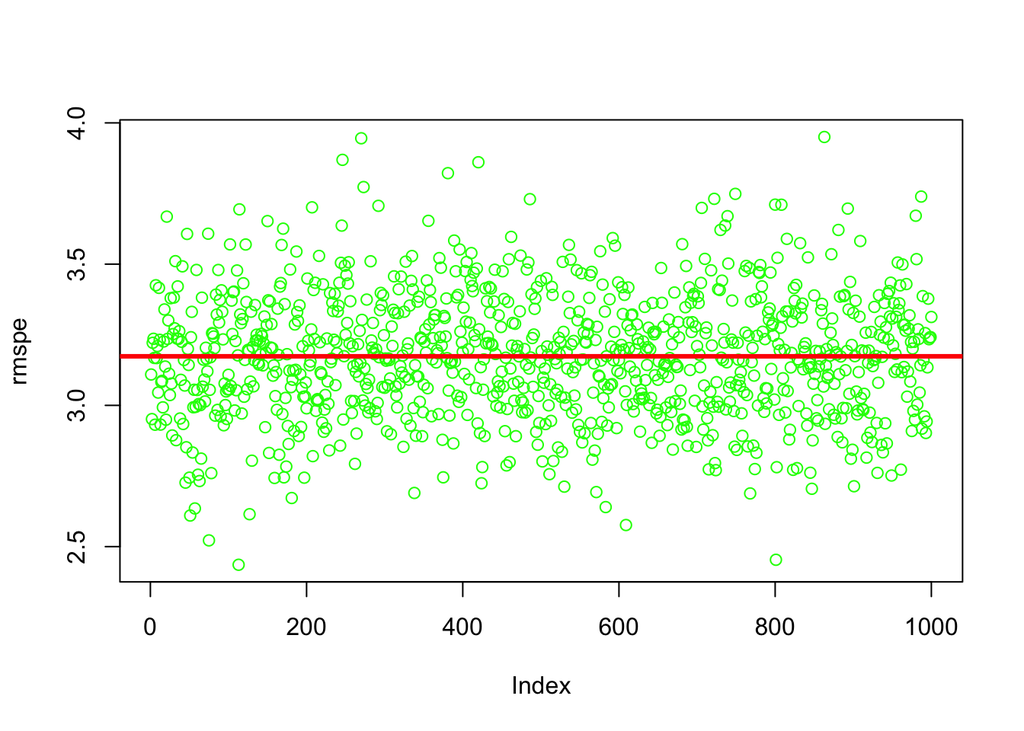

```r
rmspe <- c()
for (i in 1:1000) {
  # splitting the data
  sp1 <- sample(nrow(newdata2), nrow(newdata2) * 0.7)
  train <- newdata2[sp1, ]
  test <- newdata2[-sp1,]
  # training the model
  model1 <- lm(
    mpg ~ displacement + horsepower
    + weight + acceleration + `model year` + origin ,
    data = train
  )
  # prediction
  yhatt <- predict(model1, test)
  # Accuracy metric
  rmspe[i] <- sqrt(mean((test$mpg - yhatt) ^ 2))
}
plot(rmspe, col = "green")
abline(
  a = mean(rmspe),
  b = 0,
  col = "red",
  lwd = 3
)
```

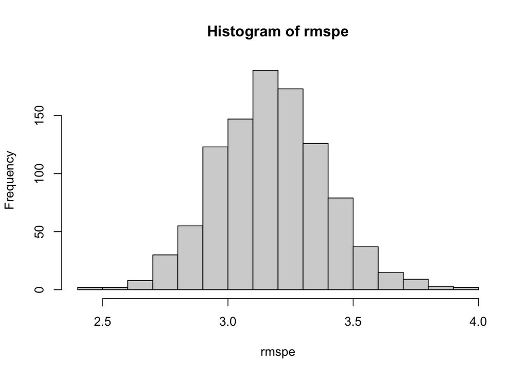

```r
hist(rmspe)
```

CLASSIFICATION

```r
library(kernlab)
data("spam")
str(spam)
```

```
## 'data.frame':    4601 obs. of  58 variables:
##  $ make             : num  0 0.21 0.06 0 0 0 0 0 0.15 0.06 ...
##  $ address          : num  0.64 0.28 0 0 0 0 0 0 0 0.12 ...
##  $ all              : num  0.64 0.5 0.71 0 0 0 0 0 0.46 0.77 ...
##  $ num3d            : num  0 0 0 0 0 0 0 0 0 0 ...
##  $ our              : num  0.32 0.14 1.23 0.63 0.63 1.85 1.92 1.88 0.61 0.19 ...
##  $ over             : num  0 0.28 0.19 0 0 0 0 0 0 0.32 ...
##  $ remove           : num  0 0.21 0.19 0.31 0.31 0 0 0 0.3 0.38 ...
##  $ internet         : num  0 0.07 0.12 0.63 0.63 1.85 0 1.88 0 0 ...
##  $ order            : num  0 0 0.64 0.31 0.31 0 0 0 0.92 0.06 ...
##  $ mail             : num  0 0.94 0.25 0.63 0.63 0 0.64 0 0.76 0 ...
##  $ receive          : num  0 0.21 0.38 0.31 0.31 0 0.96 0 0.76 0 ...
##  $ will             : num  0.64 0.79 0.45 0.31 0.31 0 1.28 0 0.92 0.64 ...
##  $ people           : num  0 0.65 0.12 0.31 0.31 0 0 0 0 0.25 ...
##  $ report           : num  0 0.21 0 0 0 0 0 0 0 0 ...
```

[output cut: 44 more lines]

```r
?spam
DF <- spam


DF$type <- ifelse(spam$type == "spam", 1, 0)
str(DF)
```

```
## 'data.frame':    4601 obs. of  58 variables:
##  $ make             : num  0 0.21 0.06 0 0 0 0 0 0.15 0.06 ...
##  $ address          : num  0.64 0.28 0 0 0 0 0 0 0 0.12 ...
##  $ all              : num  0.64 0.5 0.71 0 0 0 0 0 0.46 0.77 ...
##  $ num3d            : num  0 0 0 0 0 0 0 0 0 0 ...
##  $ our              : num  0.32 0.14 1.23 0.63 0.63 1.85 1.92 1.88 0.61 0.19 ...
##  $ over             : num  0 0.28 0.19 0 0 0 0 0 0 0.32 ...
##  $ remove           : num  0 0.21 0.19 0.31 0.31 0 0 0 0.3 0.38 ...
##  $ internet         : num  0 0.07 0.12 0.63 0.63 1.85 0 1.88 0 0 ...
##  $ order            : num  0 0 0.64 0.31 0.31 0 0 0 0.92 0.06 ...
##  $ mail             : num  0 0.94 0.25 0.63 0.63 0 0.64 0 0.76 0 ...
##  $ receive          : num  0 0.21 0.38 0.31 0.31 0 0.96 0 0.76 0 ...
##  $ will             : num  0.64 0.79 0.45 0.31 0.31 0 1.28 0 0.92 0.64 ...
##  $ people           : num  0 0.65 0.12 0.31 0.31 0 0 0 0 0.25 ...
##  $ report           : num  0 0.21 0 0 0 0 0 0 0 0 ...
```

[output cut: 44 more lines]

```r
ind <- sample(nrow(DF), nrow(DF)*0.80)
train <- DF[ind,]
test <- DF[-ind,]

model <- lm(type~., data=train)
phat <- predict(model, newdata = test)
summary(phat)
```

```
##    Min. 1st Qu.  Median    Mean 3rd Qu.    Max.
## -0.7640  0.1374  0.2747  0.3693  0.5897  3.5719
```

```r
yhat <- ifelse(phat > 0.5, 1, 0)

## 5. Build the confusion table.
ct <- table(test$type, yhat)

# This function take `ct` and make a better table
gct <- function(x) {
  conf_table <- matrix(0, 2, 2)
  conf_table[1, 1] <- ifelse(sum(dim(x)) > 3, x[2, 2], 0)
  conf_table[2, 2] <- ifelse(sum(dim(x)) > 3, x[1, 1], 0)
  conf_table[1, 2] <- ifelse(sum(dim(x)) > 3, x[2, 1], 0)
  conf_table[2, 1] <- ifelse(sum(dim(x)) > 3, x[1, 2], 0)
  colnames(conf_table) <- c("Y=1", "Y=0")
  rownames(conf_table) <- c("phat=1", "phat=0")
  conf_table
}

cont <- gct(ct)
cont
```

```
##        Y=1 Y=0
## phat=1 262  96
## phat=0  28 535
```

```r
TPR <- cont[1,1]/(cont[1,1]+cont[2,1])
TPR
```

```
## [1] 0.9034483
```

```r
#Accuracy measure
ACC <- sum(diag(cont)) / sum(cont)
ACC
```

```
## [1] 0.8653637
```

```r
##changing the threshold
yhat <- ifelse(phat > 0.45, 1, 0)

ct <- table(test$type, yhat)
cont <- gct(ct)
ACC <- sum(diag(cont)) / sum(cont)
ACC
```

```
## [1] 0.888165
```